# Human Activity Recognition

## Human Activity Recognition

- Author: Roy Tian

**Background**

Using devices such as Jawbone Up, Nike FuelBand, and Fitbit it is now possible to collect a large amount of data about personal activity relatively inexpensively. These type of devices are part of the quantified self movement – a group of enthusiasts who take measurements about themselves regularly to improve their health, to find patterns in their behavior, or because they are tech geeks. One thing that people regularly do is quantify how much of a particular activity they do, but they rarely quantify how well they do it.

Six young health participants were asked to perform one set of 10 repetitions of the Unilateral Dumbbell Biceps Curl in five different fashions: exactly according to the specification (Class A), throwing the elbows to the front (Class B), lifting the dumbbell only halfway (Class C), lowering the dumbbell only halfway (Class D) and throwing the hips to the front (Class E).

Read more: http://groupware.les.inf.puc-rio.br/har#ixzz4Yxe9P3S7

**Data Source**

http://groupware.les.inf.puc-rio.br/har

### Procedures:

1. Decide the variables should be included in the model building; (Remove zero covariates)
2. Remove NAs in train data;
3. Partition train data;
4. Try different predicton methods: tree, random forest, and support vector machine
5. Use the method with best accuracy to predict new cases from test data.

```python
# Read the test data
train.data <- read.table('pml-training.csv',sep=',',header=TRUE)
head(train.data)
```

| X | user_name | raw_timestamp_part_1 | raw_timestamp_part_2 | cvtd_timestamp | new_window | num_window | roll_belt | pitch_belt | yaw_belt | ⋯ | gyros_forearm_x | gyros_forearm_y | gyros_forearm_z | accel_forearm_x | accel_forearm_y | accel_forearm_z | magnet_forearm_x | magnet_forearm_y | magnet_forearm_z | classe |
| --- | --- | --- | --- | --- | --- | --- | --- | --- | --- | --- | --- | --- | --- | --- | --- | --- | --- | --- | --- | --- |
| 1 | carlitos | 1323084231 | 788290 | 05/12/2011 11:23 | no | 11 | 1.41 | 8.07 | -94.4 | ⋯ | 0.03 | 0.00 | -0.02 | 192 | 203 | -215 | -17 | 654 | 476 | A |
| 2 | carlitos | 1323084231 | 808298 | 05/12/2011 11:23 | no | 11 | 1.41 | 8.07 | -94.4 | ⋯ | 0.02 | 0.00 | -0.02 | 192 | 203 | -216 | -18 | 661 | 473 | A |
| 3 | carlitos | 1323084231 | 820366 | 05/12/2011 11:23 | no | 11 | 1.42 | 8.07 | -94.4 | ⋯ | 0.03 | -0.02 | 0.00 | 196 | 204 | -213 | -18 | 658 | 469 | A |
| 4 | carlitos | 1323084232 | 120339 | 05/12/2011 11:23 | no | 12 | 1.48 | 8.05 | -94.4 | ⋯ | 0.02 | -0.02 | 0.00 | 189 | 206 | -214 | -16 | 658 | 469 | A |
| 5 | carlitos | 1323084232 | 196328 | 05/12/2011 11:23 | no | 12 | 1.48 | 8.07 | -94.4 | ⋯ | 0.02 | 0.00 | -0.02 | 189 | 206 | -214 | -17 | 655 | 473 | A |
| 6 | carlitos | 1323084232 | 304277 | 05/12/2011 11:23 | no | 12 | 1.45 | 8.06 | -94.4 | ⋯ | 0.02 | -0.02 | -0.03 | 193 | 203 | -215 | -9 | 660 | 478 | A |

```python
# Load the caret pakage for Machine Learning
library(caret)
```

```python
train.data <- train.data[,-c(1:7)]
nzv <- nearZeroVar(train.data)
names(train.data)[nzv]
```

1. 'kurtosis_roll_belt'

2. 'kurtosis_picth_belt'

3. 'kurtosis_yaw_belt'

4. 'skewness_roll_belt'

5. 'skewness_roll_belt.1'

6. 'skewness_yaw_belt'

7. 'max_yaw_belt'

8. 'min_yaw_belt'

9. 'amplitude_yaw_belt'

10. 'avg_roll_arm'

11. 'stddev_roll_arm'

12. 'var_roll_arm'

13. 'avg_pitch_arm'

14. 'stddev_pitch_arm'

15. 'var_pitch_arm'

16. 'avg_yaw_arm'

17. 'stddev_yaw_arm'

18. 'var_yaw_arm'

19. 'kurtosis_roll_arm'

20. 'kurtosis_picth_arm'

21. 'kurtosis_yaw_arm'

22. 'skewness_roll_arm'

23. 'skewness_pitch_arm'

24. 'skewness_yaw_arm'

25. 'max_roll_arm'

26. 'min_roll_arm'

27. 'min_pitch_arm'

28. 'amplitude_roll_arm'

29. 'amplitude_pitch_arm'

30. 'kurtosis_roll_dumbbell'

31. 'kurtosis_picth_dumbbell'

32. 'kurtosis_yaw_dumbbell'

33. 'skewness_roll_dumbbell'

34. 'skewness_pitch_dumbbell'

35. 'skewness_yaw_dumbbell'

36. 'max_yaw_dumbbell'

37. 'min_yaw_dumbbell'

38. 'amplitude_yaw_dumbbell'

39. 'kurtosis_roll_forearm'

40. 'kurtosis_picth_forearm'

41. 'kurtosis_yaw_forearm'

42. 'skewness_roll_forearm'

43. 'skewness_pitch_forearm'

44. 'skewness_yaw_forearm'

45. 'max_roll_forearm'

46. 'max_yaw_forearm'

47. 'min_roll_forearm'

48. 'min_yaw_forearm'

49. 'amplitude_roll_forearm'

50. 'amplitude_yaw_forearm'

51. 'avg_roll_forearm'

52. 'stddev_roll_forearm'

53. 'var_roll_forearm'

54. 'avg_pitch_forearm'

55. 'stddev_pitch_forearm'

56. 'var_pitch_forearm'

57. 'avg_yaw_forearm'

58. 'stddev_yaw_forearm'

59. 'var_yaw_forearm'

```python
length(train.data[1,])
length(nzv)
```

153

59

```python
# Remove all the Near Zero Covariates
train.data <- train.data[,-c(nzv)]
dim(train.data)
```

1. 19622

2. 94

```python
NoNAs <- numeric(dim(train.data)[2])
for (i in 1:length(NoNAs)){
    NoNAs[i] <- sum(is.na(train.data[,i]))
}
NoNAs
```

1. 0

2. 0

3. 0

4. 0

5. 19216

6. 19216

7. 19216

8. 19216

9. 19216

10. 19216

11. 19216

12. 19216

13. 19216

14. 19216

15. 19216

16. 19216

17. 19216

18. 19216

19. 19216

20. 19216

21. 0

22. 0

23. 0

24. 0

25. 0

26. 0

27. 0

28. 0

29. 0

30. 0

31. 0

32. 0

33. 0

34. 19216

35. 0

36. 0

37. 0

38. 0

39. 0

40. 0

41. 0

42. 0

43. 0

44. 19216

45. 19216

46. 19216

47. 19216

48. 0

49. 0

50. 0

51. 19216

52. 19216

53. 19216

54. 19216

55. 19216

56. 19216

57. 0

58. 19216

59. 19216

60. 19216

61. 19216

62. 19216

63. 19216

64. 19216

65. 19216

66. 19216

67. 19216

68. 0

69. 0

70. 0

71. 0

72. 0

73. 0

74. 0

75. 0

76. 0

77. 0

78. 0

79. 0

80. 19216

81. 19216

82. 19216

83. 0

84. 19216

85. 0

86. 0

87. 0

88. 0

89. 0

90. 0

91. 0

92. 0

93. 0

94. 0

```python
index <- (NoNAs == 0)
train.data.cleaned <- train.data[,index]
dim(train.data.cleaned)
```

1. 19622

2. 53

```python
set.seed(2333)
inTrain <- createDataPartition(y = train.data.cleaned$classe, p = 0.7, list = FALSE)
train.set <- train.data.cleaned[inTrain,]
test.set <- train.data.cleaned[-inTrain,]
dim(train.set)
dim(test.set)
names(train.set)
```

1. 13737

2. 53

1. 5885

2. 53

1. 'roll_belt'

2. 'pitch_belt'

3. 'yaw_belt'

4. 'total_accel_belt'

5. 'gyros_belt_x'

6. 'gyros_belt_y'

7. 'gyros_belt_z'

8. 'accel_belt_x'

9. 'accel_belt_y'

10. 'accel_belt_z'

11. 'magnet_belt_x'

12. 'magnet_belt_y'

13. 'magnet_belt_z'

14. 'roll_arm'

15. 'pitch_arm'

16. 'yaw_arm'

17. 'total_accel_arm'

18. 'gyros_arm_x'

19. 'gyros_arm_y'

20. 'gyros_arm_z'

21. 'accel_arm_x'

22. 'accel_arm_y'

23. 'accel_arm_z'

24. 'magnet_arm_x'

25. 'magnet_arm_y'

26. 'magnet_arm_z'

27. 'roll_dumbbell'

28. 'pitch_dumbbell'

29. 'yaw_dumbbell'

30. 'total_accel_dumbbell'

31. 'gyros_dumbbell_x'

32. 'gyros_dumbbell_y'

33. 'gyros_dumbbell_z'

34. 'accel_dumbbell_x'

35. 'accel_dumbbell_y'

36. 'accel_dumbbell_z'

37. 'magnet_dumbbell_x'

38. 'magnet_dumbbell_y'

39. 'magnet_dumbbell_z'

40. 'roll_forearm'

41. 'pitch_forearm'

42. 'yaw_forearm'

43. 'total_accel_forearm'

44. 'gyros_forearm_x'

45. 'gyros_forearm_y'

46. 'gyros_forearm_z'

47. 'accel_forearm_x'

48. 'accel_forearm_y'

49. 'accel_forearm_z'

50. 'magnet_forearm_x'

51. 'magnet_forearm_y'

52. 'magnet_forearm_z'

53. 'classe'

```python
# Predict with Trees
fitControl <- trainControl(method = "cv",
                           number = 10,
                           repeats = 10,
                   classProbs = TRUE)
mod.tree = train (classe ~ .,
           data = train.set,
           method = "rpart",
           tuneLength = 20,
           trControl = fitControl)
```

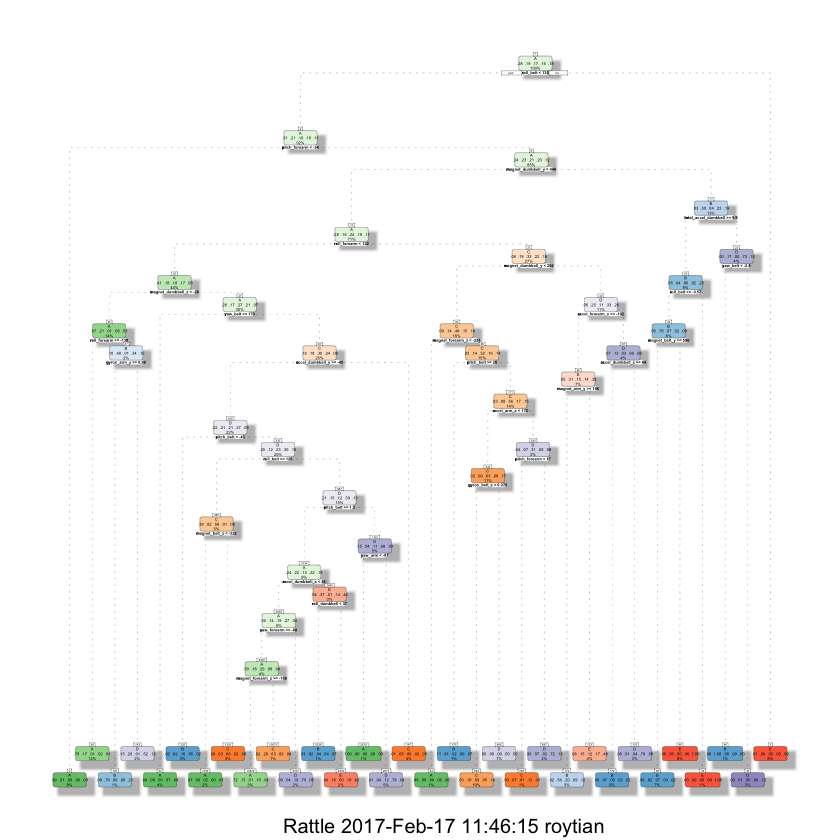

```python
library(rattle)
fancyRpartPlot(mod.tree$finalModel)
```

```python
predictions <- predict(mod.tree, newdata = test.set)
confusionMatrix(predictions, test.set$classe)
```

```
Confusion Matrix and Statistics

          Reference
Prediction    A    B    C    D    E
         A 1532  153   17   46   21
         B   38  786  104   41   63
         C   33  109  817   33   95
         D   45   42   68  790  117
         E   26   49   20   54  786

Overall Statistics

               Accuracy : 0.8005
                 95% CI : (0.7901, 0.8107)
    No Information Rate : 0.2845
    P-Value [Acc > NIR] : < 2.2e-16

                  Kappa : 0.7473
 Mcnemar's Test P-Value : < 2.2e-16

Statistics by Class:

                     Class: A Class: B Class: C Class: D Class: E
Sensitivity            0.9152   0.6901   0.7963   0.8195   0.7264
Specificity            0.9437   0.9482   0.9444   0.9447   0.9690
Pos Pred Value         0.8660   0.7616   0.7516   0.7439   0.8406
Neg Pred Value         0.9655   0.9273   0.9564   0.9639   0.9402
Prevalence             0.2845   0.1935   0.1743   0.1638   0.1839
Detection Rate         0.2603   0.1336   0.1388   0.1342   0.1336
Detection Prevalence   0.3006   0.1754   0.1847   0.1805   0.1589
Balanced Accuracy      0.9294   0.8191   0.8704   0.8821   0.8477
```

```python
# Predict with Random Forest
library(randomForest)
mod.rf <- randomForest(classe ~ ., data = train.set)

prediction.rf <- predict(mod.rf, newdata = test.set, type = 'class')
confusionMatrix(prediction.rf, test.set$classe)
```

```
Confusion Matrix and Statistics

          Reference
Prediction    A    B    C    D    E
         A 1674    0    0    0    0
         B    0 1138    8    0    0
         C    0    1 1016   10    0
         D    0    0    2  951    2
         E    0    0    0    3 1080

Overall Statistics

               Accuracy : 0.9956
                 95% CI : (0.9935, 0.9971)
    No Information Rate : 0.2845
    P-Value [Acc > NIR] : < 2.2e-16

                  Kappa : 0.9944
 Mcnemar's Test P-Value : NA

Statistics by Class:

                     Class: A Class: B Class: C Class: D Class: E
Sensitivity            1.0000   0.9991   0.9903   0.9865   0.9982
Specificity            1.0000   0.9983   0.9977   0.9992   0.9994
Pos Pred Value         1.0000   0.9930   0.9893   0.9958   0.9972
Neg Pred Value         1.0000   0.9998   0.9979   0.9974   0.9996
Prevalence             0.2845   0.1935   0.1743   0.1638   0.1839
Detection Rate         0.2845   0.1934   0.1726   0.1616   0.1835
Detection Prevalence   0.2845   0.1947   0.1745   0.1623   0.1840
Balanced Accuracy      1.0000   0.9987   0.9940   0.9929   0.9988
```

```python
# Predict with Support Vector Machine
library(e1071)
mod.svm = svm (classe ~ ., data = train.set)

prediction.svm <- predict(mod.svm, newdata = test.set)
confusionMatrix(prediction.svm, test.set$classe)
```

```
Confusion Matrix and Statistics

          Reference
Prediction    A    B    C    D    E
         A 1666   68    2    3    0
         B    4 1049   32    0    9
         C    3   21  983   77   28
         D    0    1    8  883   31
         E    1    0    1    1 1014

Overall Statistics

               Accuracy : 0.9507
                 95% CI : (0.9449, 0.9561)
    No Information Rate : 0.2845
    P-Value [Acc > NIR] : < 2.2e-16

                  Kappa : 0.9376
 Mcnemar's Test P-Value : < 2.2e-16

Statistics by Class:

                     Class: A Class: B Class: C Class: D Class: E
Sensitivity            0.9952   0.9210   0.9581   0.9160   0.9372
Specificity            0.9827   0.9905   0.9735   0.9919   0.9994
Pos Pred Value         0.9580   0.9589   0.8840   0.9567   0.9971
Neg Pred Value         0.9981   0.9812   0.9910   0.9837   0.9860
Prevalence             0.2845   0.1935   0.1743   0.1638   0.1839
Detection Rate         0.2831   0.1782   0.1670   0.1500   0.1723
Detection Prevalence   0.2955   0.1859   0.1890   0.1568   0.1728
Balanced Accuracy      0.9889   0.9558   0.9658   0.9539   0.9683
```

**Conclusion:**

The accuracy of prediction tree algorithm is much lower than that of random forest and support vector machine. Both random forest and support vector machine have an accurary over 95%. Random Forest has the best accuracy, and thus we choose to use it to predict the new cases.

```python
test.data <- read.table('pml-testing.csv',sep=',',header=TRUE)
varSelect <- names(train.set)[1:(length(names(train.set))-1)]
test.data <- test.data[,varSelect]
pred.rf <- predict(mod.rf, newdata = test.data)
pred.rf
```

**1**

B

**2**

A

**3**

B

**4**

A

**5**

A

**6**

E

**7**

D

**8**

B

**9**

A

**10**

A

**11**

B

**12**

C

**13**

B

**14**

A

**15**

E

**16**

E

**17**

A

**18**

B

**19**

B

**20**

B